# Ford GoBike System Data

## by Mostafa Mohamed Mahmoud Abdelghafaar

## Investigation Overview

> The general purpose of the report is to explain in general terms about the individual trips that are made in the bike-sharing system that covers the Greater San Francisco Bay Area and to identify the factors that drive participants to participate in trips, what distinguishes some areas from others, the percentage of participation numbers of males and females, and the time spent Some spend it and some other factors that increase our knowledge of the factors that go into trips.

## Dataset Overview

> This data set includes information about individual rides made in a bike-sharing system covering the greater San Francisco Bay area.

## Visualization about genders of participants

> This visualization show us that most of peoples are Males and The remainder nearly represent a quarter of the percentage of participants are females and others.

```
Male      130651
Female     40844
Other       3652
Name: member_gender, dtype: int64
```

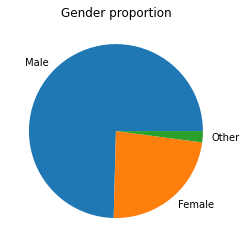

```python
#visulization show us each gender proportion in particpating in races
df_gender=df['member_gender'].dropna()
df_sorted = df_gender.value_counts()
print(df_sorted)
plt.pie(df_sorted, labels=df_sorted.index);
plt.title('Gender proportion')
```

## Visualization about ages participated and their duration in race

> I noticed that Most ages paricipate is more than 20 and less than 40 in average duration 1000 sec .

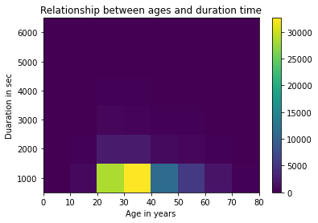

```python
# visuliztion show most ages participate and their duration in race
df['age'] = 2019 - df['member_birth_year']
bins_y = np.arange(500, 7000, 1000)
bins_x = np.arange(0, 90, 10)
plt.hist2d(df['age'], df['duration_sec'], bins = [bins_x, bins_y])
plt.colorbar()
plt.xlabel('Age in years')
plt.ylabel('Duaration in sec');
plt.title('Relationship between ages and duration time');
```

## Visualization between 3 variables genders and their ages and duration for each

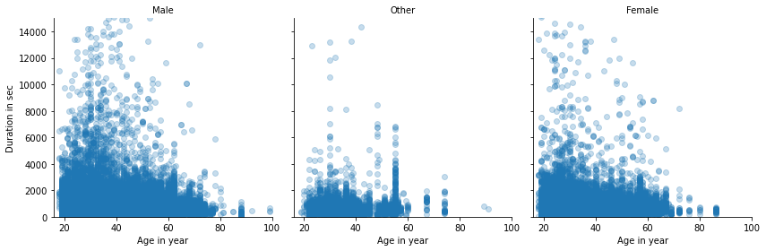

```python
#FacetGrid for relation between ages and durations in top 10 stations
g = sb.FacetGrid(data = df, col='member_gender', col_wrap=3, size = 4, xlim=[16,100], ylim=[0, 15000])
g.map(plt.scatter, 'age', 'duration_sec', alpha=0.25);
g.set_titles('{col_name}')
g.set_xlabels('Age in year')
g.set_ylabels('Duration in sec');
```